# Multiple Regression

```r
library(mosaic) # for model plots
library(mosaicData) # for our RailTrail data
library(janitor)
library(tidyverse)
library(GGally) # for pair plot
library(ggfortify) # for model diagnostics
```

# Elements of Multiple Regression

- multiple terms in regression equation
- interpretation of multiple regression
- categorical predictors (+ interpretation)
- interactions of predictors

Simple Linear Regression:

height ~ weight

Multiple Linear Regression:

volume ~ avgtemp + cloudiness + weekend

bill_length ~ species + bill_depth

ice_cream ~ temperature + sunny_day + location_glasgow

## setup - understanding the data

```r
RailTrail
```

| hightemp | lowtemp | avgtemp | spring | summer | fall | cloudcover | precip | volume | weekday | dayType |
| --- | --- | --- | --- | --- | --- | --- | --- | --- | --- | --- |
| 83 | 50 | 66.5 | 0 | 1 | 0 | 7.6 | 0.00 | 501 | TRUE | weekday |
| 73 | 49 | 61.0 | 0 | 1 | 0 | 6.3 | 0.29 | 419 | TRUE | weekday |
| 74 | 52 | 63.0 | 1 | 0 | 0 | 7.5 | 0.32 | 397 | TRUE | weekday |
| 95 | 61 | 78.0 | 0 | 1 | 0 | 2.6 | 0.00 | 385 | FALSE | weekend |
| 44 | 52 | 48.0 | 1 | 0 | 0 | 10.0 | 0.14 | 200 | TRUE | weekday |
| 69 | 54 | 61.5 | 1 | 0 | 0 | 6.6 | 0.02 | 375 | TRUE | weekday |
| 66 | 39 | 52.5 | 1 | 0 | 0 | 2.4 | 0.00 | 417 | TRUE | weekday |
| 66 | 38 | 52.0 | 1 | 0 | 0 | 0.0 | 0.00 | 629 | FALSE | weekend |
| 80 | 55 | 67.5 | 0 | 1 | 0 | 3.8 | 0.00 | 533 | FALSE | weekend |
| 79 | 45 | 62.0 | 0 | 1 | 0 | 4.1 | 0.00 | 547 | TRUE | weekday |

[output cut: 80 more lines]

## Data Preparation (Variable Engineering)

- dayType isn’t snakecase
- cloudcover isn’t one word
- some columns contain the same information (duplicate info)
- the seasonal columns are encoded as integers even though that are logical/boolean type (TRUE / FALSE) [there’s also no winter in this data]

```r
railtrail_clean <- RailTrail %>%
    clean_names() %>%
    rename(cloudage = cloudcover) %>%
    mutate(across(spring:fall, as.logical))
```

```r
head(railtrail_clean)
```

|  | hightemp | lowtemp | avgtemp | spring | summer | fall | cloudage | precip | volume | weekday | day_type |
| --- | --- | --- | --- | --- | --- | --- | --- | --- | --- | --- | --- |
| 1 | 83 | 50 | 66.5 | FALSE | TRUE | FALSE | 7.6 | 0.00 | 501 | TRUE | weekday |
| 2 | 73 | 49 | 61.0 | FALSE | TRUE | FALSE | 6.3 | 0.29 | 419 | TRUE | weekday |
| 3 | 74 | 52 | 63.0 | TRUE | FALSE | FALSE | 7.5 | 0.32 | 397 | TRUE | weekday |
| 4 | 95 | 61 | 78.0 | FALSE | TRUE | FALSE | 2.6 | 0.00 | 385 | FALSE | weekend |
| 5 | 44 | 52 | 48.0 | TRUE | FALSE | FALSE | 10.0 | 0.14 | 200 | TRUE | weekday |
| 6 | 69 | 54 | 61.5 | TRUE | FALSE | FALSE | 6.6 | 0.02 | 375 | TRUE | weekday |

`alias()` can detect perfect collinearity (this is when a variab;e can be constructed by another / a combination of other variables in the data)

```r
# volume ~ (. means every other variable)
alias(volume ~ ., data = railtrail_clean)
```

```
Model :
volume ~ hightemp + lowtemp + avgtemp + spring + summer + fall +
    cloudage + precip + weekday + day_type

Complete :
                (Intercept) hightemp lowtemp springTRUE summerTRUE cloudage precip weekdayTRUE
avgtemp           0         1/2      1/2       0          0          0        0      0
fallTRUE          1           0        0      -1         -1          0        0      0
day_typeweekend   1           0        0       0          0          0        0     -1
```

From our alias table we see that - avgtemp is a combination of lowtel and hightemp - fall is work-outable from spring and summer - day_type is work-outable from weekday

```r
# check there are no aliassed variables
alias(volume ~ ., data = railtrail_trim)
```

```
Model :
volume ~ avgtemp + spring + summer + cloudage + precip + weekday
```

## a pairs plot

- a tool for examining the relationship between all pairs of variables

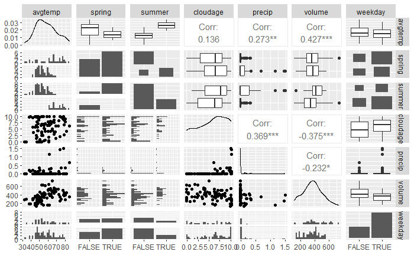

```r
ggpairs(railtrail_trim, progress = FALSE)
```

What are we looking for?

Significant relationships between:

- our outcome and any predictor
- any predictor and another predictor

Variables we might want to try modelling:

- cloudage
- avgtemp
- precip
- Summer
- weekday

## Starting point: simple linear regression

volume ~ avgtemp

cor = 0.427

volume = b0 + b1 * avgtemp

[figure not shown]

```r
summary(model)
```

```
Call:
lm(formula = volume ~ avgtemp, data = railtrail_trim)

Residuals:
    Min      1Q  Median      3Q     Max
-237.53  -80.00    8.49   55.14  326.67

Coefficients:
            Estimate Std. Error t value Pr(>|t|)
(Intercept)   99.602     63.474   1.569     0.12
avgtemp        4.802      1.084   4.428 2.72e-05 ***
---
Signif. codes:  0 ‘***’ 0.001 ‘**’ 0.01 ‘*’ 0.05 ‘.’ 0.1 ‘ ’ 1

Residual standard error: 115.9 on 88 degrees of freedom
Multiple R-squared:  0.1822,    Adjusted R-squared:  0.1729
F-statistic: 19.61 on 1 and 88 DF,  p-value: 2.723e-05
```

Model results:

avgtemp is a significant term in our model avgtemp only provides 0.18 (18%) proportion of variance explained in volume

rse = 115.9

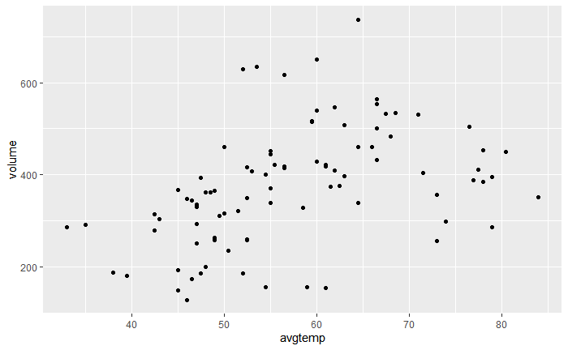

volume = b0 + b1 * avgtemp

b0 IS INTERCEPT COEFFICIENT ESTIMATE B1 IS AVGTEMP COEFFICIENT ESTIMATE

volume = 99.602 + 4.802 * 60 = 387.7

# Building a (hopefully) better model: multiple regression

Adding a categorical variable to a linear regression

Task - 2 mins Try plotting an appropriate visualisation to determine whether user volume is associated with the weekday predictor.

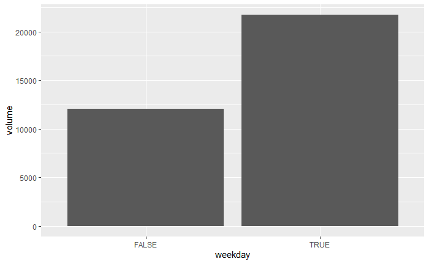

Can also grav the correlation coefficient:

| cor |
| --- |
| -0.2932675 |

-0.2932675

a weak negative correlation (expect more people using the trail on weekends compared to weekdays)

so, to add weekday to the model –

volume = b0 + b1 * avgtemp + b2 * weekday

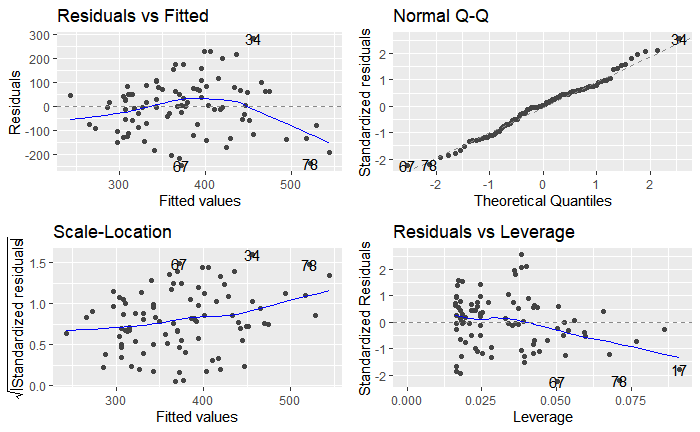

```r
model_2 <- lm(
    volume ~ avgtemp + weekday,
    data = railtrail_trim
)

autoplot(model_2)
```

```r
summary(model_2)
```

```
Call:
lm(formula = volume ~ avgtemp + weekday, data = railtrail_trim)

Residuals:
    Min      1Q  Median      3Q     Max
-242.92  -75.72    3.15   66.90  280.06

Coefficients:
            Estimate Std. Error t value Pr(>|t|)
(Intercept)  163.022     65.428   2.492  0.01461 *
avgtemp        4.541      1.050   4.323 4.08e-05 ***
weekdayTRUE  -70.320     25.566  -2.751  0.00724 **
---
Signif. codes:  0 ‘***’ 0.001 ‘**’ 0.01 ‘*’ 0.05 ‘.’ 0.1 ‘ ’ 1

Residual standard error: 111.8 on 87 degrees of freedom
Multiple R-squared:  0.2476,    Adjusted R-squared:  0.2303
F-statistic: 14.32 on 2 and 87 DF,  p-value: 4.214e-06
```

plot 1: no clear pattern to residuals plot 2: residuals appear normally distributed plot 3: again, some evidence of heteroskedasticity but variance appears reasonably uniform.

b0 = 163.022  
b1 = 4.541 b2 = -70.320

how many users if avgtemp is 65 on a saturday?

volume = b0 + b1 * avgtemp + b2 * weekday

volume = 163.02 + 4.54 * 65 + -70.32 * 0 = 458 [we’d expect 70 fewer people on a weekday]

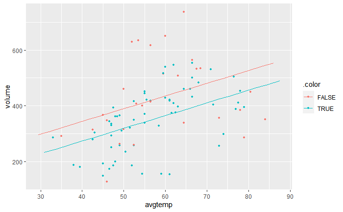

We call this a **parallel slopes model**, whether weekday is “on” or “off” the slope of the line does not change.

Task - 5 mins

Try adding the summer categorical predictor to the existing model with avgtemp and weekday.

How many lines do you expect to see in this model? Is this a parallel slopes model? [Hint try plotModel() on the model object] Is the addition of this predictor justified [Hint what is the p-value of b_summer]?

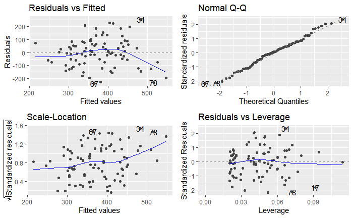

```r
model_3 <- lm(
    volume ~ avgtemp + weekday + summer,
    data = railtrail_trim
)

autoplot(model_3)
```

```r
summary(model_3)
```

```
Call:
lm(formula = volume ~ avgtemp + weekday + summer, data = railtrail_trim)

Residuals:
     Min       1Q   Median       3Q      Max
-236.165  -75.448    6.184   68.496  252.680

Coefficients:
            Estimate Std. Error t value Pr(>|t|)
(Intercept)   71.376     90.336   0.790 0.431630
avgtemp        6.387      1.639   3.898 0.000192 ***
weekdayTRUE  -66.958     25.505  -2.625 0.010244 *
summerTRUE   -59.977     41.052  -1.461 0.147662
---
Signif. codes:  0 ‘***’ 0.001 ‘**’ 0.01 ‘*’ 0.05 ‘.’ 0.1 ‘ ’ 1

Residual standard error: 111.1 on 86 degrees of freedom
Multiple R-squared:  0.2659,    Adjusted R-squared:  0.2402
F-statistic: 10.38 on 3 and 86 DF,  p-value: 6.714e-06
```

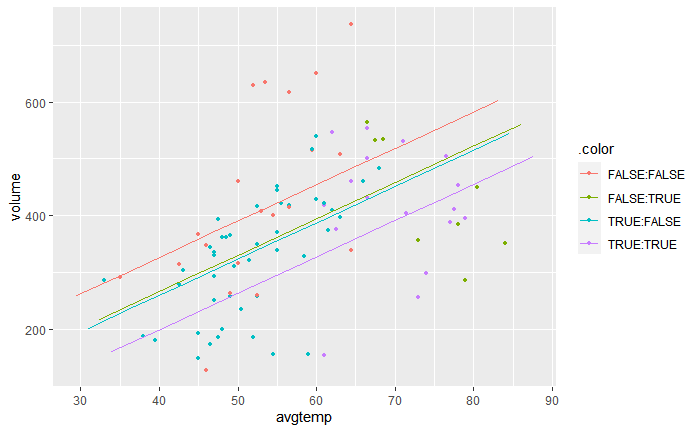

```r
plotModel(model_3)
```

As summer does not seem to be a statistically significant term in our model (perhaps due to high variation being explained from avgtemp already), we won’t add it as a term

Current model:

volume ~ avgtemp + weekday

- interactions: terms involving two or more predictors

Does the volume of users on the trail depend on whether or not it’s a weekday and how does temperature factor into this?

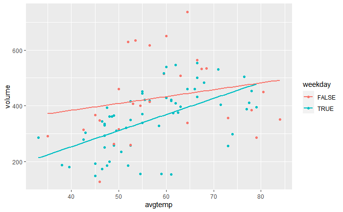

```r
railtrail_trim %>%
    ggplot(aes(x = avgtemp, y = volume, colour = weekday)) +
    geom_point() +
    geom_smooth(method = "lm", se = FALSE)
```

What does this say?

The two lines have different gradients. On a weekday, increasing the avgtemp results in a larger increase in users.

How do we add this into our model?

- add an interaction

volume = b0 + b1 * avgtemp + b2 * weekday + b3 * avgtemp * weekday

equation of the two lines:

when weekday = 0 volume = b0 + b1 * avgtemp

when weekday = 1 volume = b0 + b1 * avgtemp + b2 + b3 * avgtemp

or in it’s “simplest” form volume = (b0 + b2) + (b1 + b3) * avgtemp

formula is volume varies with average temp and weekday and the interaction of avg temp and weekday

```r
summary(model_interaction)
```

```
Call:
lm(formula = volume ~ avgtemp + weekday + avgtemp:weekday, data = railtrail_trim)

Residuals:
     Min       1Q   Median       3Q      Max
-269.906  -78.862    2.064   68.190  291.641

Coefficients:
                    Estimate Std. Error t value Pr(>|t|)
(Intercept)          285.887    103.390   2.765  0.00696 **
avgtemp                2.457      1.718   1.431  0.15619
weekdayTRUE         -262.193    128.181  -2.045  0.04386 *
avgtemp:weekdayTRUE    3.300      2.161   1.527  0.13040
---
Signif. codes:  0 ‘***’ 0.001 ‘**’ 0.01 ‘*’ 0.05 ‘.’ 0.1 ‘ ’ 1

Residual standard error: 111 on 86 degrees of freedom
Multiple R-squared:  0.2675,    Adjusted R-squared:  0.2419
F-statistic: 10.47 on 3 and 86 DF,  p-value: 6.115e-06
```

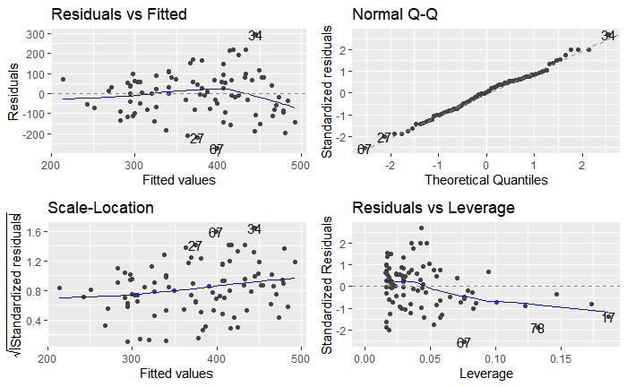

While the diagnostic plots look fine (ish - still a bit of heteroskedasticity in Scale-Location), the p-vlaues suggest the interaction is not statistically significant.

```r
model_3terms <- lm(
    volume ~ avgtem + weekday + cloudage,
    data = railtrail_trim
)
```

```
Error in eval(predvars, data, env) : object 'avgtem' not found
```

```r
summary(model_3terms)
```

[output not shown]

Interpreting this

volume = b0 + b1 * avgtemp + b2 * weekday + b3 * cloudage

y = ax + bz + c

how many users on a saturday if 5 cloudage and 55F

406 422 411